# Analiza wzorców w statystykach drużyn NCAA

Autor

Afiliacja

Jakub Żołdak

Politechnika Lubelska

Opublikowano

16 stycznia 2026

# Wstęp

## Research motivation (dlaczego wybrałem taki obszar badań)

Celem tego projektu jest zbadanie wskaźników wydajności drużyn koszykarskich NCAA w latach 2013–2024. Wybór tego tematu wynika z chęci zrozumienia, jakie czynniki statystyczne odróżniają drużyny odnoszące sukcesy od tych, które radzą sobie gorzej. Wynika rónież z mojego zainteresowania koszykówką :)

## Co będzie tematem danego projektu

Tematem projektu jest eksploracyjna analiza danych (EDA) zestawu danych NCAA o koszykówce. NCAA to skrót oznaczający National Collegiate Athletic Association Będę, i będziemy analizować najwyższą dywizję (ligę) czyli D1. Będę starał się znaleźć wzorce występujące w drużynach wygrywających i przegrywających oraz ogólnie przyjrzeć się temu zbiorowi danych.

[figure not shown]

Drabinka turnieju March Madness z 2025 roku w którym udział wzięło 68 z 255 możliwych drużyn

## Pytania badawcze

Na podstawie dostępnych danych postawiłem następujące pytania badawcze:

1. **Które statystyki wykazują najsilniejszą korelację z liczbą wygranych meczów (`W`)?**
2. **Jak skuteczność rzutów (za 2 i za 3 punkty) wpływa na sukces drużyny i jak zmienia się to w czasie?**
3. **Czym charakteryzują się “drużyny zwycięskie” (powyżej określonego progu zwycięstw) i które programy utrzymują ten status na przestrzenii lat**

## Podgląd zbioru danych

|  | TEAM | CONF | G | W | ADJOE | ADJDE | BARTHAG | EFG_O | EFG_D | TOR | TORD | ORB | DRB | FTR | FTRD | X2P_O | X2P_D | X3P_O | X3P_D | ADJ_T | WAB | POSTSEASON | SEED | YEAR | POSTSEASON_NUM | WIN_P |
| --- | --- | --- | --- | --- | --- | --- | --- | --- | --- | --- | --- | --- | --- | --- | --- | --- | --- | --- | --- | --- | --- | --- | --- | --- | --- | --- |
| 1 | North Carolina | ACC | 40 | 33 | 123.3 | 94.9 | 0.9531 | 52.6 | 48.1 | 15.4 | 18.2 | 40.7 | 30 | 32.3 | 30.4 | 53.9 | 44.6 | 32.7 | 36.2 | 71.7 | 8.6 | 2ND | 1 | 2016 | 2 | 0.825 |
| 2 | Wisconsin | B10 | 40 | 36 | 129.1 | 93.6 | 0.9758 | 54.8 | 47.7 | 12.4 | 15.8 | 32.1 | 23.7 | 36.2 | 22.4 | 54.8 | 44.7 | 36.5 | 37.5 | 59.3 | 11.3 | 2ND | 1 | 2015 | 2 | 0.9 |
| 3 | Michigan | B10 | 40 | 33 | 114.4 | 90.4 | 0.9375 | 53.9 | 47.7 | 14 | 19.5 | 25.5 | 24.9 | 30.7 | 30 | 54.7 | 46.8 | 35.2 | 33.2 | 65.9 | 6.9 | 2ND | 3 | 2018 | 2 | 0.825 |
| 4 | Texas Tech | B12 | 38 | 31 | 115.2 | 85.2 | 0.9696 | 53.5 | 43 | 17.7 | 22.8 | 27.4 | 28.7 | 32.9 | 36.6 | 52.8 | 41.9 | 36.5 | 29.7 | 67.5 | 7 | 2ND | 3 | 2019 | 2 | 0.8157894736842105 |
| 5 | Gonzaga | WCC | 39 | 37 | 117.8 | 86.3 | 0.9728 | 56.6 | 41.1 | 16.2 | 17.1 | 30 | 26.2 | 39 | 26.9 | 56.3 | 40 | 38.2 | 29 | 71.5 | 7.7 | 2ND | 1 | 2017 | 2 | 0.9487179487179487 |
| 6 | Kentucky | SEC | 40 | 29 | 117.2 | 96.2 | 0.9062 | 49.9 | 46 | 18.1 | 16.1 | 42 | 29.7 | 51.8 | 36.8 | 50 | 44.9 | 33.2 | 32.2 | 65.9 | 3.9 | 2ND | 8 | 2014 | 2 | 0.725 |
| 7 | Michigan | B10 | 38 | 30 | 121.5 | 93.7 | 0.9522 | 54.6 | 48 | 14.6 | 18.7 | 32.5 | 29.4 | 28.4 | 22.7 | 53.4 | 47.6 | 37.9 | 32.6 | 64.8 | 6.2 | 2ND | 4 | 2013 | 2 | 0.7894736842105263 |
| 8 | Duke | ACC | 39 | 35 | 125.2 | 90.6 | 0.9764 | 56.6 | 46.5 | 16.3 | 18.6 | 35.8 | 30.2 | 39.8 | 23.9 | 55.9 | 46.3 | 38.7 | 31.4 | 66.4 | 10.7 | Champions | 1 | 2015 | 1 | 0.8974358974358975 |
| 9 | Virginia | ACC | 38 | 35 | 123 | 89.9 | 0.9736 | 55.2 | 44.7 | 14.7 | 17.5 | 30.4 | 25.4 | 29.1 | 26.3 | 52.5 | 45.7 | 39.5 | 28.9 | 60.7 | 11.1 | Champions | 1 | 2019 | 1 | 0.9210526315789473 |
| 10 | North Carolina | ACC | 39 | 33 | 121 | 91.5 | 0.9615 | 51.7 | 48.1 | 16.2 | 18.6 | 41.3 | 25 | 34.3 | 31.6 | 51 | 46.3 | 35.5 | 33.9 | 72.8 | 8.4 | Champions | 1 | 2017 | 1 | 0.8461538461538461 |

[output cut: 3875 more lines]

## Jakie zmienne zawiera nasz zbiór?

Zbiór obejmuje kluczowe statystyki, takie jak:

- Ilość wygranych meczów (`W`),
- Skorygowana efektywność ofensywna (`ADJOE`) i defensywna (`ADJDE`)
- Procent skuteczności za dwa i trzy (`X2P_O` i `X3P_O`)
- Procent wygranych meczów w skali sezonu (`WIN_P`)

Dane obejmują sezony 2013-2024 (z wyłączeniem turnieju w 2020 r. w tym roku się nie odbył ze względu na pandemię COVID-19).

# Pytanie badawcze 1: Które statystyki wykazują najsilniejszą korelację z liczbą wygranych meczów?

Używamy macierzy korelacji, aby zidentyfikować związki między zmiennymi numerycznymi.

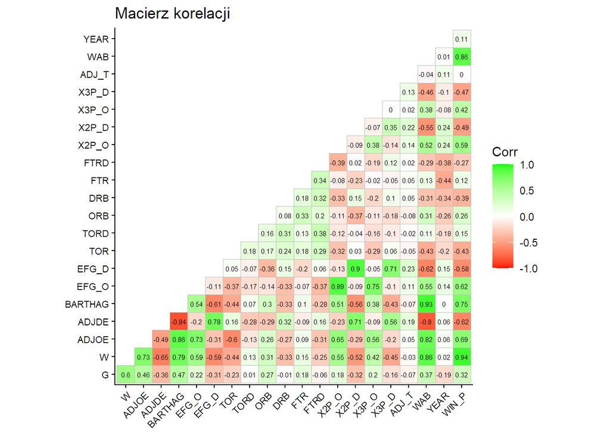

Filtrujemy tylko silne korelacje (> 0.5) dla lepszej czytelności.

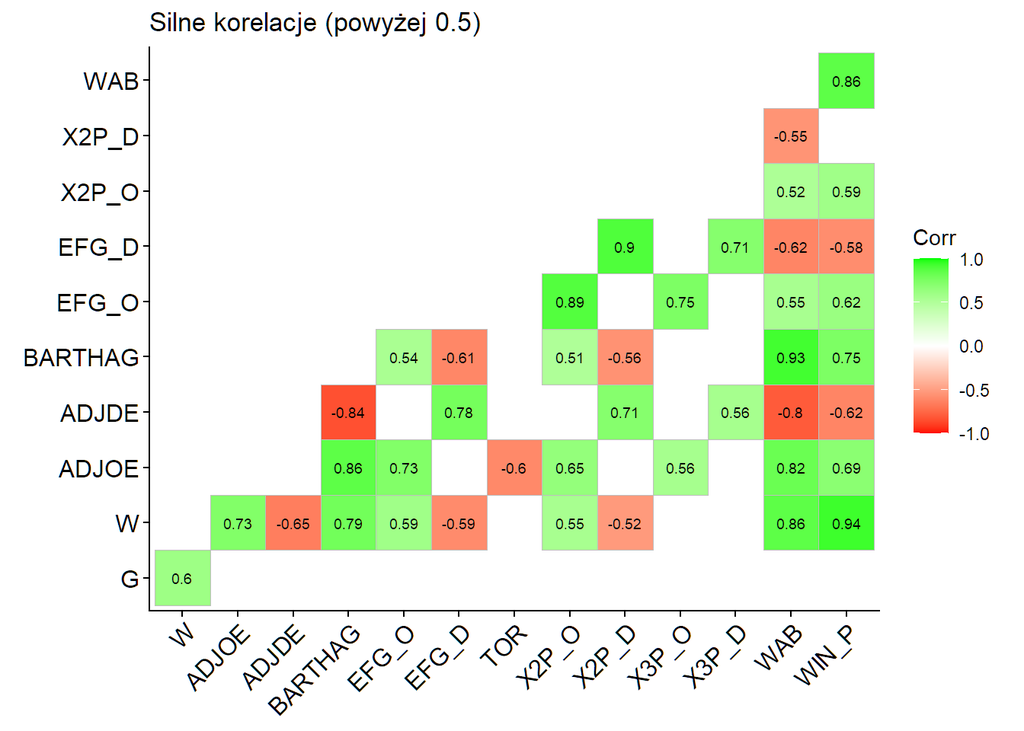

Interpretacja: Macierz wskazuje na silną korelację (0.73) między `ADJOE` a `W`. Poniższy wykres punktowy to potwierdza – drużyny z wyższym `ADJOE` wygrywają więcej i częściej zachodzą daleko w fazie pucharowej (prawa górna część wykresu).

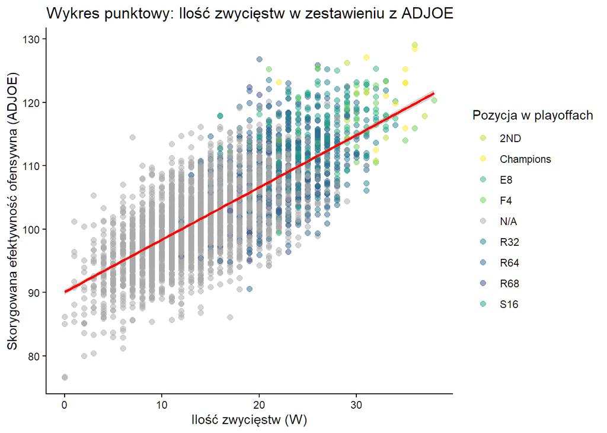

# Pytanie badawcze 2: Jak skuteczność rzutów wpływa na sukces?

Rzuty za 2 punkty to zmienna (`X2P_O`)

Korelacja między ilością zwycięstw w naszej macierzy korelacji wyszła nam na poziomie 0.55. Przyjmujemy próg 50% jako wyznacznik dobrej skuteczności za 2 jak w tym poście na [quora](https://www.quora.com/In-the-NBA-why-is-shooting-50-from-two-point-range-considered-excellent-but-shooting-33-from-3-point-range-is-considered-substandard-when-both-percentages-equal-one-point-per-shot).

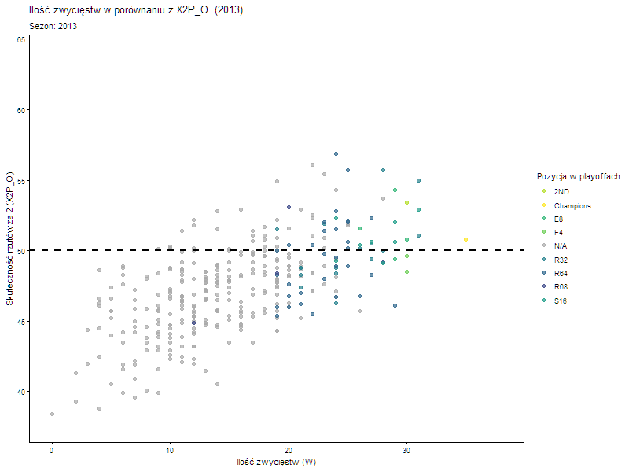

Interpretacja: Drużyny wygrywające zazwyczaj znajdują się powyżej linii 50%.

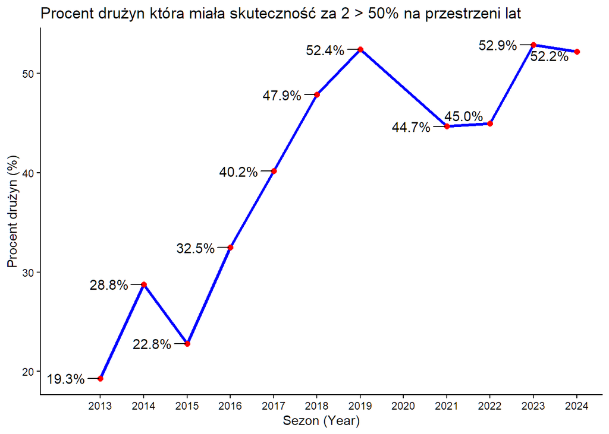

Rzuty za 3 punkty to zmienna (`X3P_O`)

Korelacja która wyszła w naszej macierzy korelacji wcześniej jest słabsza niż przy rzutach za dwa bo wynosi zaledwie (0.42). Przyjmujemy próg 38% dla “elitarnej” skuteczności za 3 (ciekawy wątek odnośnie rzutów za 3 na [reddit](https://www.reddit.com/r/dataisbeautiful/comments/bxu2xv/oc_three_point_shooting_in_the_nba_and_ncaa/)).

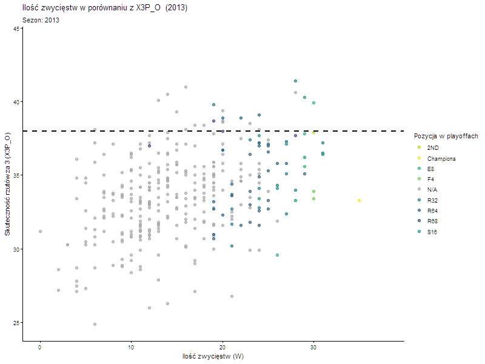

Interpretacja: Niewiele drużyn osiąga ten próg, a ich liczba spada na przestrzeni lat, co może wynikać z lepszej defensywy lub zmian w przepisach (odległości linii rzutów za 3).

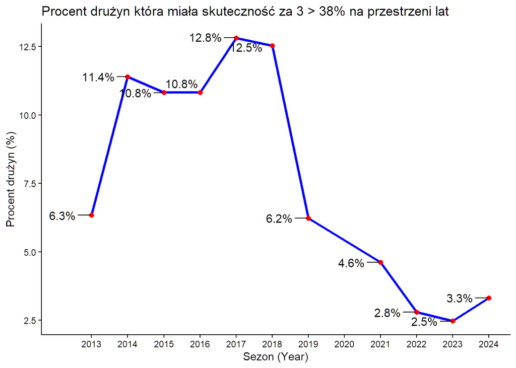